# Understanding Data Structures with Hierarchical Clustering

Unsupervised Learning, Clustering, Hierarchical Clustering (Agglomerative vs. Divisive), Dendrograms, Linkage Criteria (Single, Complete, Average, Ward's), Proximity Matrix.

### **Objectives:**

- Students will understand the principles of **unsupervised learning** and the goal of clustering to find inherent groupings in data.
- Students will differentiate between partitional clustering (like K-Means) and the nested cluster structure produced by **hierarchical clustering**.
- Students will grasp the intuition behind **agglomerative ("bottom-up") hierarchical clustering**.
- Students will understand and compare the four main **linkage criteria** (Single, Complete, Average, Ward's) and their impact on cluster shape.
- Students will learn to generate and interpret **dendrograms** to visualize the cluster hierarchy and determine an appropriate number of clusters.
- Students will implement hierarchical clustering using both `scipy` (for dendrograms) and `scikit-learn` (for cluster assignment).
- Students will apply the technique to a real-world dataset, visualize the results, and derive meaningful profiles for each cluster.

### **Setup: Install and Import Libraries**

We will use `scikit-learn` for the clustering algorithm and `scipy` for its powerful dendrogram plotting capabilities.

```python
# No special installs are needed as these are standard in Colab
# Import libraries
import pandas as pd
import numpy as np
import matplotlib.pyplot as plt
import seaborn as sns
import sklearn

# Scikit-learn for clustering and preprocessing
from sklearn.preprocessing import StandardScaler
from sklearn.cluster import AgglomerativeClustering

# Scipy for dendrograms
import scipy.cluster.hierarchy as sch

# Set plot style for better aesthetics
sns.set_theme(style="whitegrid")
sns.set_context("notebook", font_scale=1.2)


# Suppress warnings for cleaner output
import warnings
warnings.filterwarnings('ignore')

print(f"Pandas Version: {pd.__version__}")
print(f"Scikit-learn Version: {sklearn.__version__}")
```

```
Pandas Version: 2.2.2
Scikit-learn Version: 1.6.1
```

### **Part 1: Dataset & The Goal of Clustering**

We will use the **"Mall Customers" dataset**, which contains information about customers, including their annual income and a "spending score" (from 1-100). This dataset is ideal for clustering because it has clear, intuitive customer segments that we can discover.

Our goal is to use hierarchical clustering to identify these distinct customer groups based on their income and spending habits without any prior labels.

**Important:** As hierarchical clustering is a distance-based algorithm, we **must** scale our features to ensure that one feature (like income) doesn't dominate the other (spending score).

```
--- Part 1: Dataset Loading and Preparation ---
```

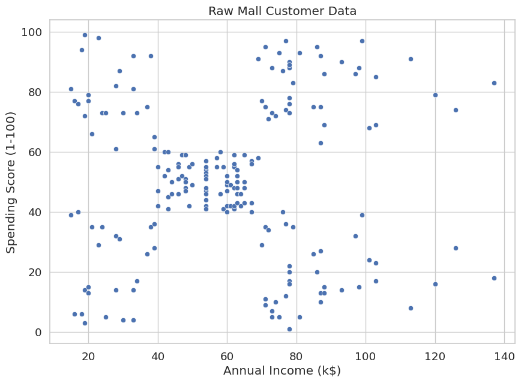

```
Data has been standardized.
```

```python
print("--- Part 1: Dataset Loading and Preparation ---")

# 1. Load the dataset from a public URL
url = 'https://raw.githubusercontent.com/SteffiPeTaffy/machineLearningAZ/master/Machine%20Learning%20A-Z%20Template%20Folder/Part%204%20-%20Clustering/Section%2025%20-%20Hierarchical%20Clustering/Mall_Customers.csv'
df = pd.read_csv(url)

# 2. Select the relevant features for clustering
X = df[['Annual Income (k$)', 'Spending Score (1-100)']]

# 3. Visualize the raw data to see the inherent clusters
plt.figure(figsize=(10, 7))
sns.scatterplot(x='Annual Income (k$)', y='Spending Score (1-100)', data=X)
plt.title('Raw Mall Customer Data')
plt.xlabel('Annual Income (k$)')
plt.ylabel('Spending Score (1-100)')
plt.show()

# 4. Scale the features
scaler = StandardScaler()
X_scaled = scaler.fit_transform(X)
print("\nData has been standardized.")
```